# ERA Explained

Mojisoluwa (Jiso) Awe

# What is ERA?

Earned Run Average (ERA) is a measure of the average amount runs a pitcher gives up during a game. The higher a pitchers ERA, the more runs a pitcher has given up. ERA is traditionally a go to way of analyzing a pitchers effectiveness, seeing as it is a defense independent pitching statistics (DIPS). In this notebook we will be analyzing different pitchers ERA’s and some additional factors that can influence them.

### Calculation

$$\frac {9*Earned Runs}{Innings Pitched}$$

The calculation of ERA is done by multiplying the number of earned runs off of a pitcher divided by the number of innings they pitched and multiplied by nine (for the nine innings in a full game). If there are players on base when the pitcher leaves, any runs scored by said players would count against the pitcher. The lower the ERA, the better. This stat gives an estimation for the number of runs earned a pitcher would have given up if they were to pitch for a full game.

```r
library(ggplot2)   ##loading libraries
library(dplyr)
library(tidyverse)
library(ggExtra)
library(hrbrthemes)
```

# Team ERA’s

Data Provided by: https://www.baseball-reference.com/leagues/majors/2021-standard-pitching.shtml on July 13th

```r
tpitch <-  ##Team Standard Pitching data from Baseball Reference
  read.csv('TeamPitching21.csv')
tpitch
```

| Tm | X.P | PAge | RA.G | W | L | W.L. | ERA | G | GS | GF | CG | tSho | cSho | SV | IP | H | R | ER | HR | BB | IBB | SO | HBP | BK | WP | BF | ERA. | FIP | WHIP | … |
| --- | --- | --- | --- | --- | --- | --- | --- | --- | --- | --- | --- | --- | --- | --- | --- | --- | --- | --- | --- | --- | --- | --- | --- | --- | --- | --- | --- | --- | --- | --- |
| ARI | 32 | 28.7 | 5.77 | 26 | 66 | 0.283 | 5.41 | 92 | 92 | 90 | 2 | 3 | 2 | 9 | 798.0 | 864 | 531 | 480 | 135 | 315 | 27 | 706 | 46 | 6 | 26 | 3575 | 76 | 4.95 | 1.477 | … |
| ATL | 26 | 29.4 | 4.51 | 44 | 45 | 0.494 | 4.24 | 89 | 89 | 89 | 0 | 10 | 0 | 19 | 774.0 | 716 | 401 | 365 | 104 | 303 | 16 | 796 | 37 | 3 | 47 | 3326 | 105 | 4.17 | 1.317 | … |
| BAL | 30 | 28.4 | 5.64 | 28 | 61 | 0.315 | 5.60 | 89 | 89 | 88 | 1 | 2 | 1 | 15 | 768.2 | 820 | 502 | 478 | 136 | 319 | 5 | 746 | 33 | 4 | 45 | 3418 | 81 | 4.90 | 1.482 | … |
| BOS | 23 | 29.9 | 4.47 | 55 | 36 | 0.604 | 4.09 | 91 | 91 | 91 | 0 | 3 | 0 | 29 | 805.1 | 807 | 407 | 366 | 93 | 311 | 11 | 848 | 41 | 3 | 31 | 3483 | 114 | 3.87 | 1.388 | … |
| CHC | 29 | 30.2 | 4.47 | 44 | 46 | 0.489 | 4.13 | 90 | 90 | 89 | 1 | 5 | 0 | 23 | 789.0 | 697 | 402 | 362 | 117 | 341 | 11 | 792 | 54 | 2 | 31 | 3407 | 96 | 4.59 | 1.316 | … |
| CWS | 21 | 28.2 | 3.81 | 54 | 35 | 0.607 | 3.58 | 89 | 89 | 86 | 3 | 8 | 3 | 26 | 766.2 | 659 | 339 | 305 | 98 | 269 | 9 | 885 | 27 | 4 | 47 | 3215 | 120 | 3.68 | 1.210 | … |
| CIN | 26 | 28.9 | 4.74 | 48 | 42 | 0.533 | 4.38 | 90 | 90 | 89 | 1 | 5 | 1 | 26 | 798.2 | 720 | 427 | 389 | 109 | 370 | 23 | 866 | 38 | 5 | 34 | 3474 | 106 | 4.30 | 1.365 | … |
| CLE | 21 | 26.1 | 4.54 | 45 | 42 | 0.517 | 4.42 | 87 | 87 | 87 | 0 | 5 | 0 | 22 | 751.2 | 668 | 395 | 369 | 113 | 312 | 6 | 814 | 28 | 5 | 36 | 3205 | 104 | 4.31 | 1.304 | … |
| COL | 20 | 28.3 | 4.81 | 40 | 51 | 0.440 | 4.60 | 91 | 91 | 88 | 3 | 4 | 1 | 16 | 782.0 | 757 | 438 | 400 | 103 | 314 | 11 | 696 | 38 | 2 | 34 | 3376 | 100 | 4.45 | 1.370 | … |
| DET | 27 | 27.4 | 5.02 | 40 | 51 | 0.440 | 4.74 | 91 | 91 | 89 | 2 | 2 | 1 | 19 | 786.1 | 769 | 457 | 414 | 116 | 321 | 5 | 722 | 52 | 1 | 51 | 3440 | 92 | 4.67 | 1.386 | … |

[output cut: 20 more lines]

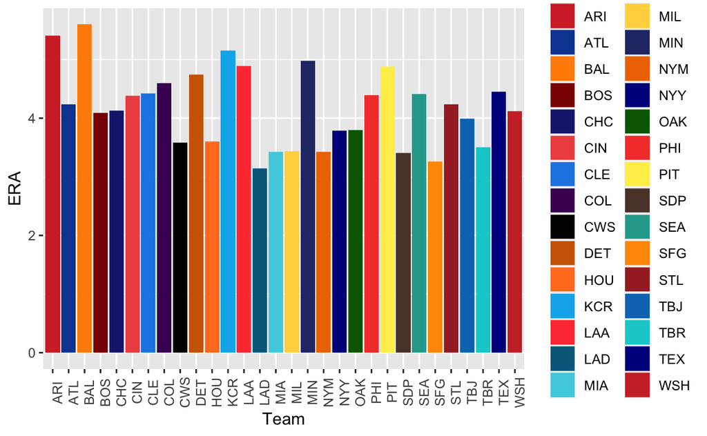

```r
eragr <-
  tpitch %>%
  ggplot(aes(x = Tm, y = ERA, fill = Tm)) +
  geom_bar(stat = 'identity') +
  xlab('Team') +
  theme(axis.text.x = element_text(angle = 90)) +
  scale_fill_manual(values = c('ARI' = '#D32F2F',
                               'ATL' = '#0D47A1',
                               'BAL' = 'darkorange',
                               'BOS' = 'darkred',
                               'CHC' = '#1A237E',
                               'CWS' = 'black',
                               'CIN' = '#EF5350',
                               'CLE' = '#1E88E5',
                               'COL' = '#4b0062',
                               'DET' = 'darkorange3',
                               'HOU' = 'chocolate1',
                               'KCR' = 'deepskyblue2',
                               'LAA' = 'brown1',
                               'LAD'= 'deepskyblue4',
                               'MIA'= '#4DD0E1',
                               'MIL'= '#FFD54F',
                               'MIN'= '#283573',
                               'NYY' = 'blue4',
                               'NYM' = 'darkorange2',
                               'OAK' = 'darkgreen',
                               'PHI'= '#F44336',
                               'PIT'= '#FFEE58',
                               'SDP' = '#5d4037',
                               'SEA' = '#26A69A',
                               'SFG'= '#FF9800',
                               'STL'= 'brown',
                               'TBR' = 'darkturquoise',
                               'TEX' = 'darkblue',
                               'TBJ' = '#0277BD',
                               'WSH' = 'brown3'))
eragr
```

The graph above details the ERA of each team in the MLB, with the average ERA being about 4.18…

# Pitch Type

```r
spin <-
  read.csv('active-spin.csv')
spin
```

| last_name | first_name | pitch_hand | active_spin_fourseam | active_spin_sinker | active_spin_cutter | active_spin_changeup | active_spin_fastball | active_spin_slider | active_spin_curve |
| --- | --- | --- | --- | --- | --- | --- | --- | --- | --- |
| Springs | Jeffrey | L | NA | 98.9 | NA | 98.7 | NA | 29.6 | NA |
| Yarbrough | Ryan | L | NA | 97.6 | 43.3 | 94.3 | NA | NA | 74.7 |
| Rodriguez | Chris | R | NA | 91.4 | NA | 97.2 | NA | 26.3 | 77.3 |
| Rowen | Ben | R | NA | 77.3 | NA | NA | NA | 81.2 | NA |
| Scrubb | Andre | R | NA | NA | 67.4 | NA | NA | NA | 88.4 |
| Holland | Derek | L | NA | 99.0 | NA | 93.9 | NA | NA | 17.4 |
| Sadler | Casey | R | NA | 84.1 | 29.2 | NA | NA | NA | 58.9 |
| Garcia | Bryan | R | NA | 96.1 | NA | 97.5 | NA | 29.0 | NA |
| Matz | Steven | L | NA | 99.6 | NA | 88.1 | NA | 36.8 | 82.0 |
| Eshelman | Thomas | R | NA | 81.0 | NA | 93.7 | NA | 40.6 | 61.2 |

[output cut: 555 more lines]

```r
spgr <-
  spin%>%
  ggplot(aes(x = active_spin_sinker, y = active_spin_fourseam, color =pitch_hand)) +
  geom_point(stat = 'identity') +
  xlab('Sinker Speed (mph)') +
  ylab('Fourseam Speed (mph)')

p1 <-
  ggMarginal(spgr, type = 'histogram', fill = 'grey', size = 3)
```

```
Removed 339 rows containing missing values (geom_point).
```

[figure not shown]

```r
p1
```